# An introduction to R for psychologists

### What if we induce a difference ? i.e. $H_1$ is true

> Try it yourself, induce a difference on a t.test using rnorm()

Reminder :

```r
t.test(rnorm(10, mean_iq, std_iq),rnorm(10, mean_iq+15, std_iq))
```

```
	Welch Two Sample t-test

data:  rnorm(10, mean_iq, std_iq) and rnorm(10, mean_iq + 15, std_iq)
t = -2.0176, df = 16.619, p-value = 0.06008
alternative hypothesis: true difference in means is not equal to 0
95 percent confidence interval:
 -24.9783583   0.5799511
sample estimates:
mean of x mean of y
 101.1489  113.3481
```

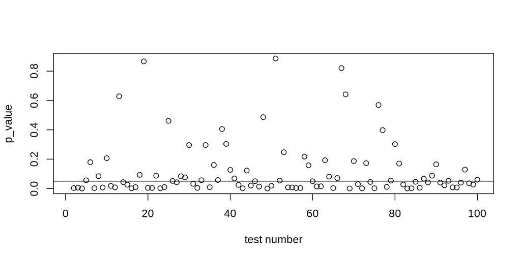

```r
n_rep = 100 #100 tests repeated
n_per_group = 10#10 persons in each group
vector_p_values = NULL
for (i in 2:n_rep){
    grp1 = rnorm(n_per_group, mean_iq, std_iq)
    grp2 = rnorm(n_per_group, mean_iq-std_iq, std_iq)#H1 is true
    vector_p_values[i] <- t.test(grp1,grp2)$p.value
}
plot(1:n_rep, vector_p_values, xlab='test number', ylab='p_value')
abline(h=0.05)
```

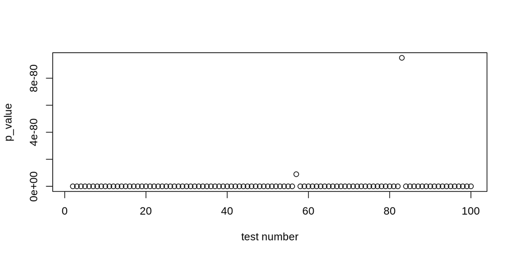

```r
n_rep = 100 #100 tests repeated
n_per_group = 1000 # INCREASED TO 1000
vector_p_values = NULL
for (i in 2:n_rep){
    grp1 = rnorm(n_per_group, mean_iq, std_iq)
    grp2 = rnorm(n_per_group, mean_iq-std_iq, std_iq)
    vector_p_values[i] <- t.test(grp1,grp2)$p.value
}
plot(1:n_rep, vector_p_values, xlab='test number', ylab='p_value')
abline(h=0.05)
```

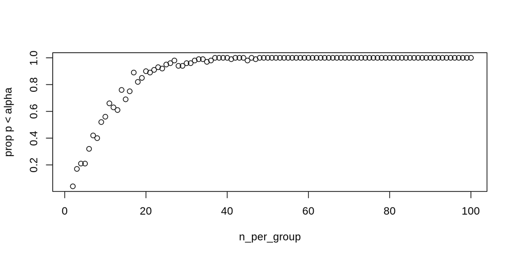

```r
n_rep = 100
max_n_per_group = 100
alpha = 0.05 # Significance threshold
vector_p_values = NULL
for (n_i in 2:max_n_per_group){#CHANGED
    p_val_for_n_i = NULL
    for (i in 1:n_rep){
        grp1 = rnorm(n_i, mean_iq, std_iq)
        grp2 = rnorm(n_i, mean_iq-std_iq, std_iq)
        p_val_for_n_i[i] <- ifelse(t.test(grp1,grp2)$p.value < alpha, 1, 0)
        }
    vector_p_values[n_i] <- mean(p_val_for_n_i)
}
plot(1:max_n_per_group, vector_p_values, xlab='n_per_group', ylab='prop p < alpha')
```

> Play with the alpha level

```r
vector_p_values_at_alpha5 = vector_p_values
```

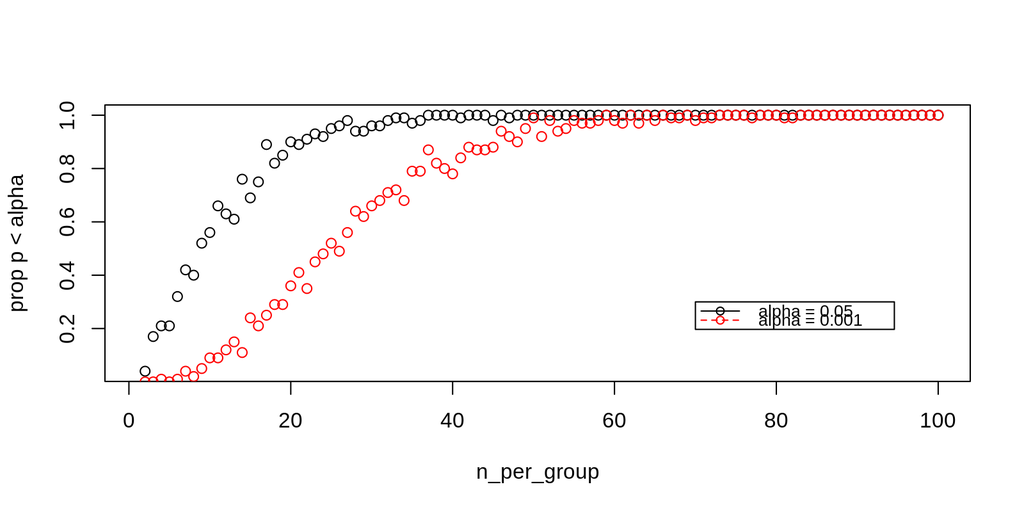

```r
n_rep = 100
max_n_per_group = 100
alpha = 0.001 # Significance threshold
vector_p_values = NULL
for (n_i in 2:max_n_per_group){#CHANGED
    p_val_for_n_i = NULL
    for (i in 1:n_rep){
        grp1 = rnorm(n_i, mean_iq, std_iq)
        grp2 = rnorm(n_i, mean_iq-std_iq, std_iq)
        p_val_for_n_i[i] <- ifelse(t.test(grp1,grp2)$p.value < alpha, 1, 0)
        }
    vector_p_values[n_i] <- mean(p_val_for_n_i)
}
plot(1:max_n_per_group, vector_p_values_at_alpha5, xlab='n_per_group', ylab='prop p < alpha')
points(1:max_n_per_group, vector_p_values, col='red', xlab='n_per_group', ylab='prop p < alpha')

legend(70, 0.3, legend=c("alpha = 0.05", "alpha = 0.001"),
       col=c("black", "red"), lty=1:2, cex=0.8, pch=1)
```

## What about confidence intervals ?

```r
t.test(rnorm(10, mean_iq, std_iq),rnorm(10, mean_iq, std_iq))
```

```
	Welch Two Sample t-test

data:  rnorm(10, mean_iq, std_iq) and rnorm(10, mean_iq, std_iq)
t = -0.9569, df = 17.987, p-value = 0.3513
alternative hypothesis: true difference in means is not equal to 0
95 percent confidence interval:
 -20.198718   7.557373
sample estimates:
mean of x mean of y
 98.85844 105.17912
```

Definition ?

Lets test it

```r
n_rep = 100 #100 tests repeated
n_per_group = 10#10 persons in each group
matrix_ci_values = NULL
for (i in 1:n_rep){
    grp1 = rnorm(n_per_group, mean_iq, std_iq)
    grp2 = rnorm(n_per_group, mean_iq-std_iq, std_iq)#H1 is true
    matrix_ci_values <- rbind(matrix_ci_values,matrix(c(t.test(grp1,grp2)$conf.int[1],t.test(grp1,grp2)$conf.int[2]), ncol=2,nrow=1) )
}
ci_corr = matrix_ci_values[(std_iq >= matrix_ci_values[,1]) & (std_iq <= matrix_ci_values[,2]),]#true included in CI
ci_incorr = matrix_ci_values[(std_iq >= matrix_ci_values[,2]) | (std_iq <= matrix_ci_values[,1]),]#true not included in CI
```

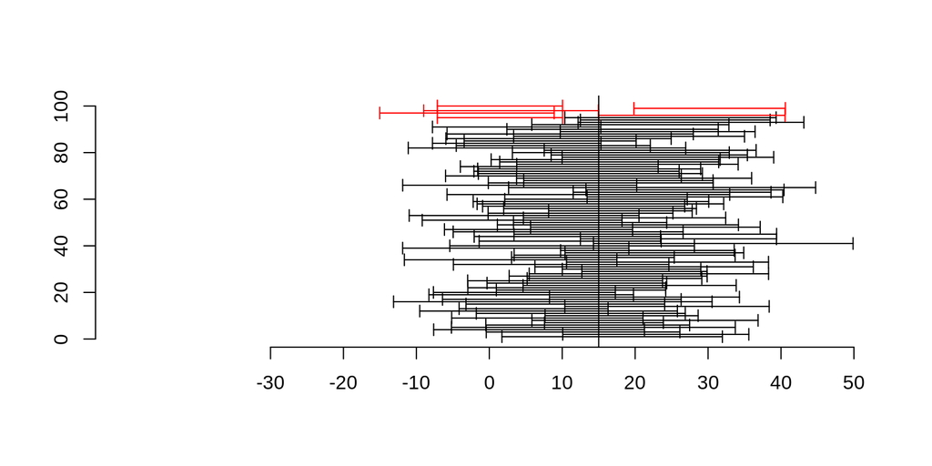

```r
#Graphical  parameters
plot.new()
plot.window(xlim=c(-50,50), ylim=c(0.5, 100+.5), ylab="a")
axis(1, at=seq(-30, 50, by=10))
axis(2, at=seq(0, 100, by=20))

#Plotting correct CI vs incorrect
arrows(ci_corr[,1], 1:nrow(ci_corr), ci_corr[,2], 1:nrow(ci_corr), code=3, length=0.05, angle=90)
arrows(ci_incorr[,1], nrow(ci_corr):(nrow(ci_incorr)+nrow(ci_corr)), ci_incorr[,2],
       nrow(ci_corr):(nrow(ci_incorr)+nrow(ci_corr)), code=3, length=0.05, angle=90,col="red")
#Plotting true effect as a line
abline(v=std_iq)
```

The true effect is contained in 95\% of the CIs

# Moving to a real psychological experiment

```r
library(curl)#library shipped with R-recommended install, used to download from URL
```

```r
download.file("https://raw.githubusercontent.com/GWeindel/DecomposingRT/master/Raw_data/markers/MRK_SAT_M2.csv",
    destfile = "test.csv", method = "curl")#Downloading to test.csv
```

```r
head(read.csv2("test.csv",sep=","),2)#Reading csv and displaying first two rows
```

A data.frame: 2 × 20

|  | participant <fct> | contraste <int> | condition <fct> | expdResp <fct> | trialType <fct> | response <fct> | nbrA <fct> | CA <fct> | IA <fct> | rt <fct> | pmt <fct> | mt <fct> | Apmt <fct> | FlaTime <fct> | ForceTime <fct> | chanEMG1 <fct> | trial <int> | givenResp <fct> | com <fct> | EMGtrial <fct> |
| --- | --- | --- | --- | --- | --- | --- | --- | --- | --- | --- | --- | --- | --- | --- | --- | --- | --- | --- | --- | --- |
| 1 | S16 | 1 | Accuracy | Right | SA | 1.0 | 1.0 | 1.0 | 0.0 | 1001.953125 | 901.85546875 | 100.09765625 | 901.85546875 |  |  |  | 1 | Right | 0.0 | C |
| 2 | S16 | 2 | Accuracy | Right | SA | 1.0 | 1.0 | 1.0 | 0.0 | 800.29296875 | 681.15234375 | 119.140625 | 681.15234375 |  |  |  | 2 | Right | 0.0 | C |

```r
ls()
```

1. 'alpha'

2. 'ci_corr'

3. 'ci_incorr'

4. 'grp1'

5. 'grp2'

6. 'i'

7. 'matrix_ci_values'

8. 'max_n_per_group'

9. 'mean_iq'

10. 'n_i'

11. 'n_per_group'

12. 'n_rep'

13. 'p_val_for_n_i'

14. 'samples'

15. 'std_iq'

16. 'upper_bound'

17. 'vector_mean_iq'

18. 'vector_p_values'

19. 'vector_p_values_at_alpha5'

```r
df = read.csv2("test.csv",sep=",",dec=".")
df = df[c("participant","contraste","condition","rt")]
```

```r
head(df)
```

A data.frame: 6 × 4

|  | participant <fct> | contraste <int> | condition <fct> | rt <dbl> |
| --- | --- | --- | --- | --- |
| 1 | S16 | 1 | Accuracy | 1001.9531 |
| 2 | S16 | 2 | Accuracy | 800.2930 |
| 3 | S16 | 1 | Accuracy | 700.6836 |
| 4 | S16 | 2 | Accuracy | 877.9297 |
| 5 | S16 | 3 | Accuracy | 938.4766 |
| 6 | S16 | 4 | Accuracy | 814.9414 |

# Exploring your data

```r
summary(df)
```

```
  participant      contraste    condition           rt
 S10    : 2400   Min.   :1   Accuracy:16800   Min.   :   2.441
 S12    : 2400   1st Qu.:2   Speed   :16800   1st Qu.: 354.492
 S13    : 2400   Median :3                    Median : 435.059
 S14    : 2400   Mean   :3                    Mean   : 482.078
 S15    : 2400   3rd Qu.:4                    3rd Qu.: 560.059
 S16    : 2400   Max.   :5                    Max.   :1498.535
 (Other):19200                                NA's   :168
```

```r
df$rt = as.numeric(df$rt)
```

```r
summary(df)
```

```
  participant      contraste    condition           rt
 S10    : 2400   Min.   :1   Accuracy:16800   Min.   :   2.441
 S12    : 2400   1st Qu.:2   Speed   :16800   1st Qu.: 354.492
 S13    : 2400   Median :3                    Median : 435.059
 S14    : 2400   Mean   :3                    Mean   : 482.078
 S15    : 2400   3rd Qu.:4                    3rd Qu.: 560.059
 S16    : 2400   Max.   :5                    Max.   :1498.535
 (Other):19200                                NA's   :168
```

```r
unique(df$participant)
```

1. S16

2. S13

3. S17

4. s3

5. S7

6. S15

7. S9

8. S5

9. S6

10. S4

11. S14

12. S2

13. S10

14. S12

**Levels**:**

1. 'S10'

2. 'S12'

3. 'S13'

4. 'S14'

5. 'S15'

6. 'S16'

7. 'S17'

8. 'S2'

9. 's3'

10. 'S4'

11. 'S5'

12. 'S6'

13. 'S7'

14. 'S9'

```r
unique(df$condition)
```

1. Accuracy

2. Speed

**Levels**:**

1. 'Accuracy'

2. 'Speed'

```r
unique(df$contraste)
```

1. 1

2. 2

3. 3

4. 4

5. 5

# Exploring your data

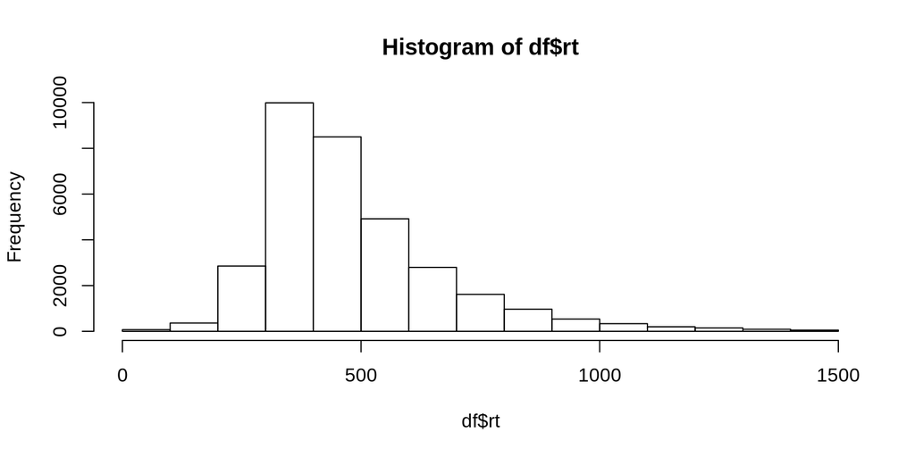

```r
hist(df$rt)
```

But this is for the group, each individual has 2400 trials :

```r
for (parti in unique(df$participant)){#Unefficient
    print(c(parti,length(df[df$participant == parti,'rt'])))
}
```

```
[1] "S16"  "2400"
[1] "S13"  "2400"
[1] "S17"  "2400"
[1] "s3"   "2400"
[1] "S7"   "2400"
[1] "S15"  "2400"
[1] "S9"   "2400"
[1] "S5"   "2400"
[1] "S6"   "2400"
[1] "S4"   "2400"
[1] "S14"  "2400"
[1] "S2"   "2400"
[1] "S10"  "2400"
[1] "S12"  "2400"
```

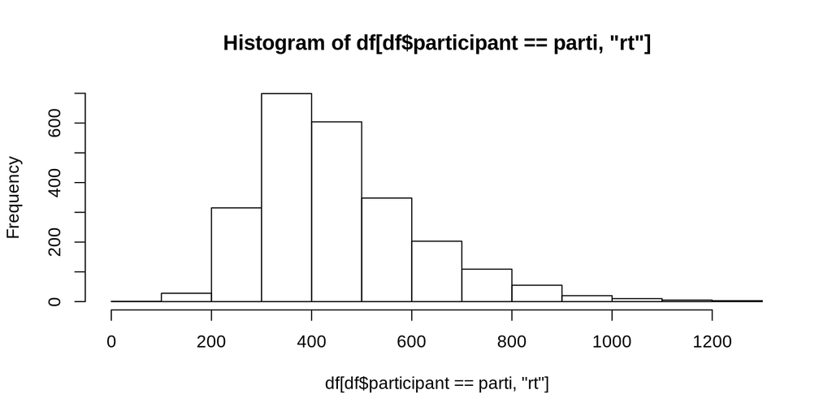

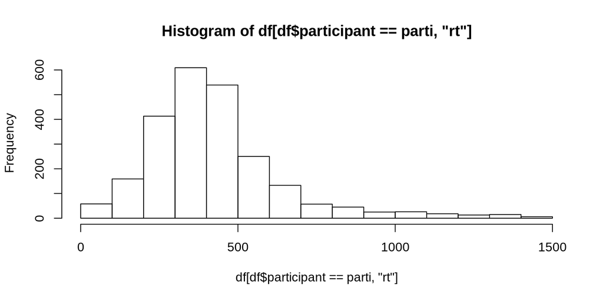

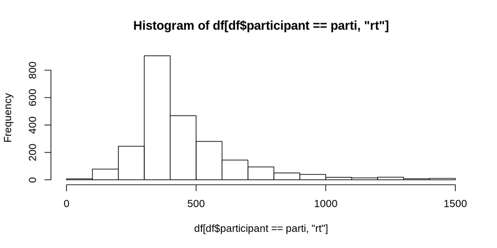

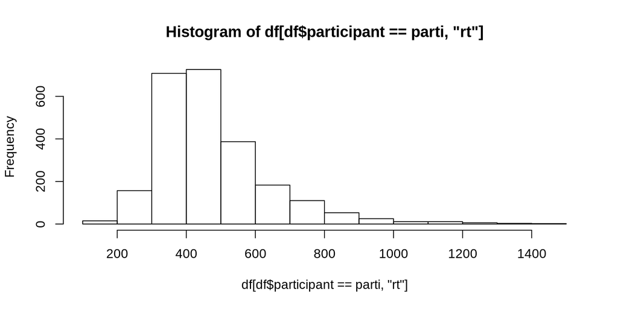

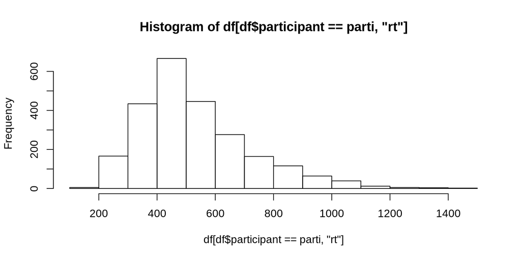

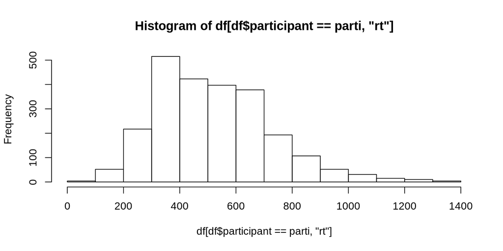

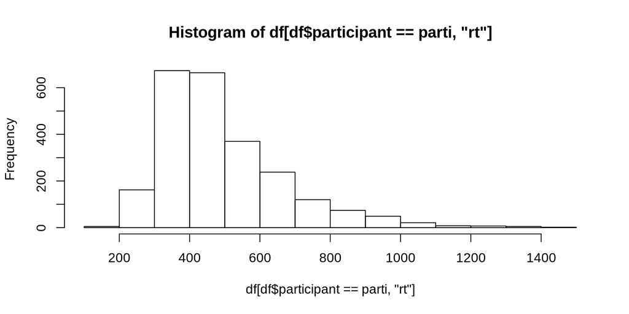

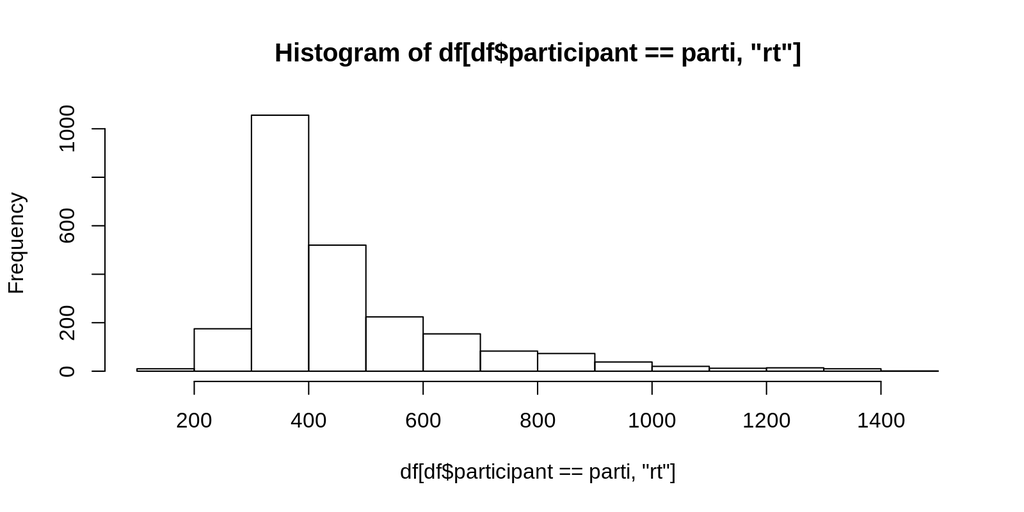

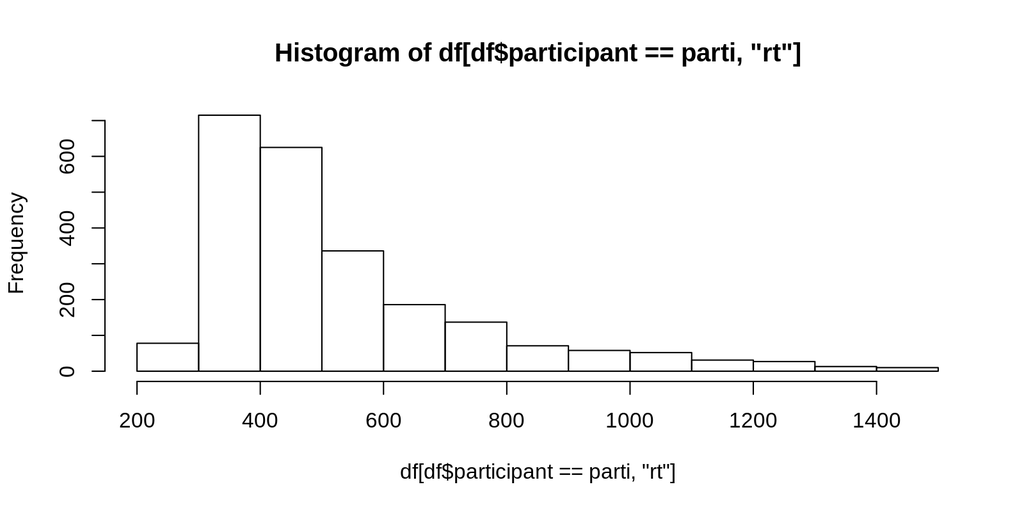

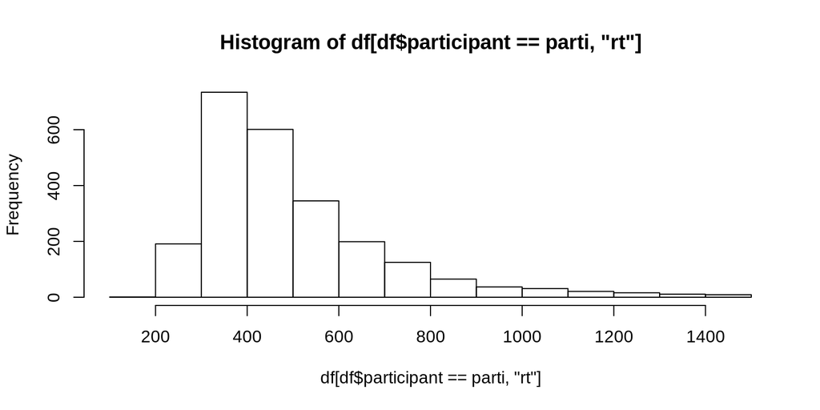

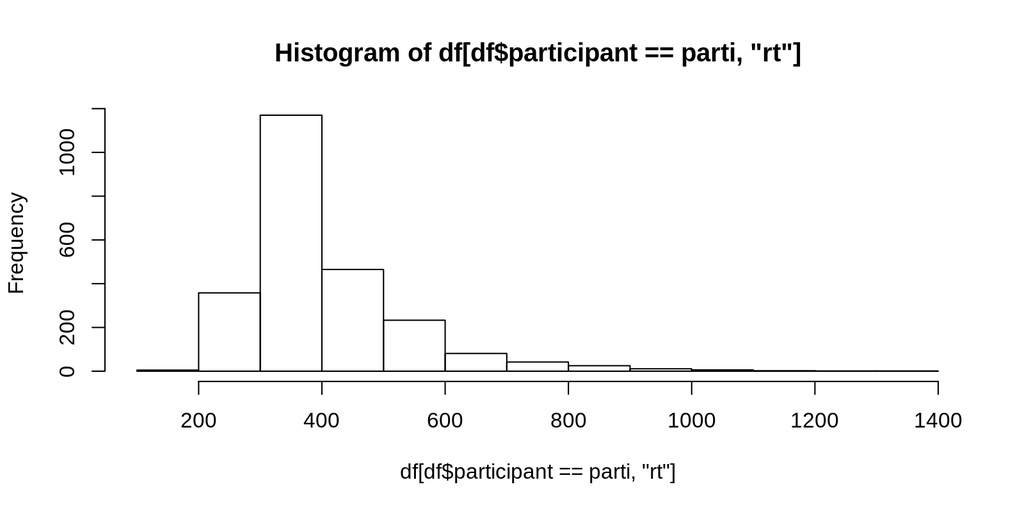

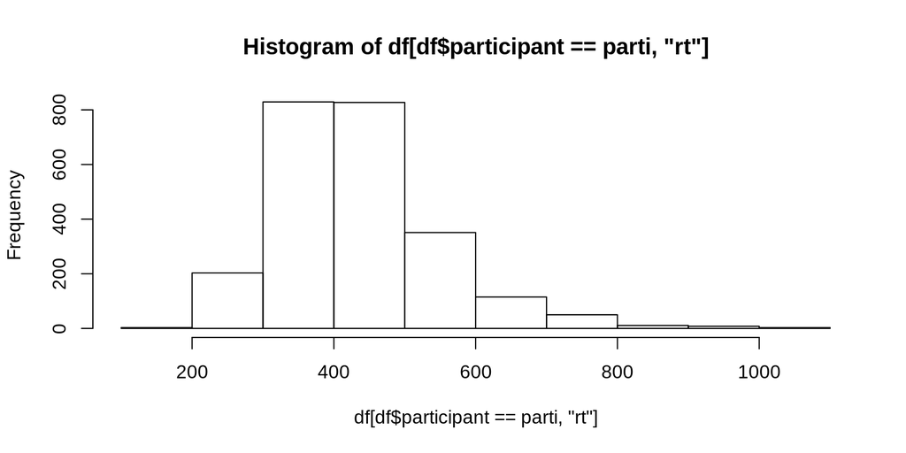

[2 more figures not shown]

```r
for (parti in unique(df$participant)){#Unefficient
    hist(df[df$participant == parti,'rt'])
}
```

## Data wrangling

In this dataset some RTs were not recorded :

```r
df[is.na(df$rt),]
```

A data.frame: 168 × 4

|  | participant <fct> | contraste <int> | condition <fct> | rt <dbl> |
| --- | --- | --- | --- | --- |
| 2708 | S13 | 1 | Accuracy | NA |
| 2744 | S13 | 3 | Accuracy | NA |
| 2752 | S13 | 1 | Accuracy | NA |
| 2783 | S13 | 3 | Accuracy | NA |
| 2840 | S13 | 4 | Accuracy | NA |
| 2868 | S13 | 2 | Accuracy | NA |
| 2874 | S13 | 4 | Accuracy | NA |
| 2933 | S13 | 1 | Accuracy | NA |
| 2986 | S13 | 2 | Accuracy | NA |
| 3000 | S13 | 5 | Accuracy | NA |
| 3199 | S13 | 2 | Speed | NA |
| 3425 | S13 | 2 | Accuracy | NA |
| 3524 | S13 | 5 | Accuracy | NA |
| 3615 | S13 | 1 | Speed | NA |
| 3638 | S13 | 2 | Speed | NA |
| 3643 | S13 | 4 | Speed | NA |
| 3743 | S13 | 4 | Speed | NA |
| 3846 | S13 | 1 | Speed | NA |
| 3958 | S13 | 5 | Accuracy | NA |
| 3982 | S13 | 4 | Accuracy | NA |
| 4073 | S13 | 2 | Accuracy | NA |
| 4095 | S13 | 1 | Accuracy | NA |
| 4142 | S13 | 3 | Accuracy | NA |
| 4167 | S13 | 4 | Accuracy | NA |
| 4181 | S13 | 3 | Accuracy | NA |
| 4261 | S13 | 1 | Speed | NA |
| 4289 | S13 | 3 | Speed | NA |
| 4349 | S13 | 3 | Speed | NA |
| 4350 | S13 | 4 | Speed | NA |
| 4377 | S13 | 3 | Speed | NA |
| ⋮ | ⋮ | ⋮ | ⋮ | ⋮ |
| 21792 | S4 | 1 | Accuracy | NA |
| 21799 | S4 | 3 | Accuracy | NA |
| 22353 | S4 | 1 | Accuracy | NA |
| 22359 | S4 | 5 | Accuracy | NA |
| 22387 | S4 | 2 | Accuracy | NA |
| 22490 | S4 | 3 | Accuracy | NA |
| 23018 | S4 | 4 | Accuracy | NA |
| 23073 | S4 | 3 | Accuracy | NA |
| 23655 | S4 | 1 | Accuracy | NA |
| 23674 | S4 | 4 | Accuracy | NA |
| 28940 | S10 | 1 | Accuracy | NA |
| 29595 | S10 | 4 | Accuracy | NA |
| 29682 | S10 | 3 | Accuracy | NA |
| 30042 | S10 | 2 | Accuracy | NA |
| 30632 | S10 | 2 | Accuracy | NA |
| 30715 | S10 | 3 | Accuracy | NA |
| 30730 | S10 | 2 | Accuracy | NA |
| 30731 | S10 | 1 | Accuracy | NA |
| 30742 | S10 | 1 | Accuracy | NA |
| 30743 | S10 | 1 | Accuracy | NA |
| 30752 | S10 | 1 | Accuracy | NA |
| 30757 | S10 | 1 | Accuracy | NA |
| 30760 | S10 | 3 | Accuracy | NA |
| 30805 | S10 | 3 | Accuracy | NA |
| 30899 | S10 | 3 | Accuracy | NA |
| 31381 | S12 | 1 | Accuracy | NA |
| 31401 | S12 | 3 | Accuracy | NA |
| 32497 | S12 | 1 | Accuracy | NA |
| 33087 | S12 | 3 | Accuracy | NA |
| 33129 | S12 | 1 | Accuracy | NA |

And some are unreaseonably too short :

```r
min(df[!is.na(df$rt),'rt'])#note the use of "!"
```

2.44140625

We therefore would like to have a subset of the data were RTs were recorded and represent a genuine reaction time

```r
nona_df = df[!is.na(df$rt),]
prepocessed_df = nona_df[nona_df$rt>200,]#>200 ms is arbitrary and inappropriate
```

OR

```r
prepocessed_df = df[!is.na(df$rt) & df$rt>200,]
```

Is it the same ?

```r
length(nona_df[nona_df$rt>200,]) == length(df[!is.na(df$rt) & df$rt>200,])
```

TRUE

```r
summary(prepocessed_df)
```

```
  participant      contraste        condition           rt
 S2     : 2397   Min.   :1.000   Accuracy:16593   Min.   : 200.2
 S14    : 2395   1st Qu.:2.000   Speed   :16405   1st Qu.: 357.9
 S7     : 2394   Median :3.000                    Median : 437.5
 S12    : 2393   Mean   :3.005                    Mean   : 486.5
 S9     : 2393   3rd Qu.:4.000                    3rd Qu.: 562.5
 S4     : 2385   Max.   :5.000                    Max.   :1498.5
 (Other):18641
```

We could do the same for any other variable,

> e.g. try to remove one participant

```r
unique(prepocessed_df[prepocessed_df$participant != "S16",'participant'])
```

1. S13

2. S17

3. s3

4. S7

5. S15

6. S9

7. S5

8. S6

9. S4

10. S14

11. S2

12. S10

13. S12

**Levels**:**

1. 'S10'

2. 'S12'

3. 'S13'

4. 'S14'

5. 'S15'

6. 'S16'

7. 'S17'

8. 'S2'

9. 's3'

10. 'S4'

11. 'S5'

12. 'S6'

13. 'S7'

14. 'S9'

But we have no reason to remove that participant so we don't store this trim

# Plotting

Let's plot the data ! (in base R)

```r
head(aggregate(rt~participant*condition , data=prepocessed_df , mean))
```

A data.frame: 6 × 3

|  | participant <fct> | condition <fct> | rt <dbl> |
| --- | --- | --- | --- |
| 1 | S10 | Accuracy | 663.6109 |
| 2 | S12 | Accuracy | 616.6359 |
| 3 | S13 | Accuracy | 503.1480 |
| 4 | S14 | Accuracy | 409.5335 |
| 5 | S15 | Accuracy | 645.8327 |
| 6 | S16 | Accuracy | 525.9041 |

```r
ind_means = aggregate(rt~participant*condition , data=prepocessed_df , mean)
grand_means = aggregate(rt ~ condition, data=ind_means, mean)
```

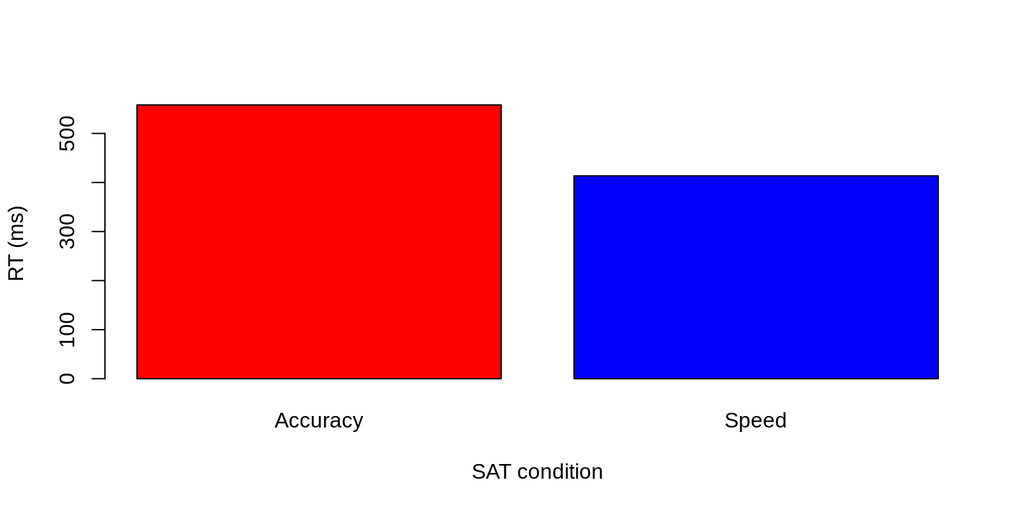

```r
barplot(rt ~ condition, data=grand_means, ylab='RT (ms)',
   xlab="SAT condition",  col=c("red","blue"))
```

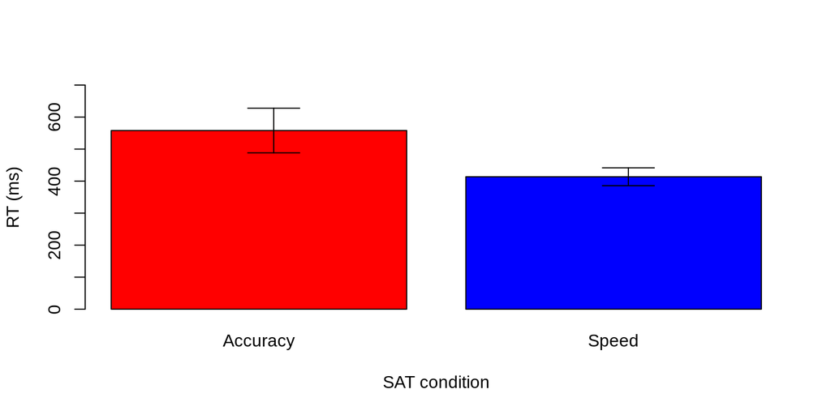

```r
grand_std = aggregate(rt ~ condition, data=ind_means, sd)

barplot(rt ~ condition, data=grand_means, ylab='RT (ms)',
   xlab="SAT condition",  col=c("red","blue"), ylim=c(0,700))

arrows(.75,grand_means$rt[1] + grand_std$rt[1], .75, grand_means$rt[1] - grand_std$rt[1], angle=90, code=3)
arrows(1.95,grand_means$rt[2] + grand_std$rt[2], 1.95, grand_means$rt[2] - grand_std$rt[2], angle=90, code=3)
```

> Perform the same for the contrast manipulation (only for the condition where participants needed to be accurate). Skip the dispersion (e.g. std)

Barplot ?

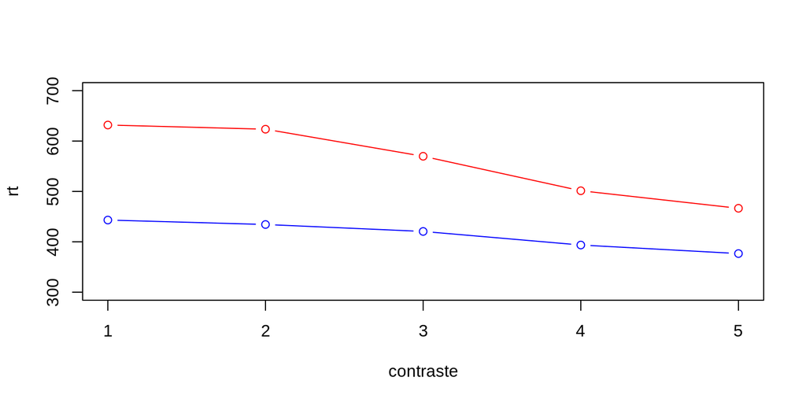

```r
ind_means_acc = aggregate(rt~participant*contraste , data=prepocessed_df[prepocessed_df$condition == "Accuracy",] , mean)
grand_mean_acc = aggregate(rt ~ contraste, data=ind_means_acc, mean)

ind_means_spd = aggregate(rt~participant*contraste , data=prepocessed_df[prepocessed_df$condition == "Speed",] , mean)
grand_mean_spd = aggregate(rt ~ contraste, data=ind_means_spd, mean)

plot(grand_mean_acc, type="b", ylim=c(300,700), col='red')
lines(grand_mean_spd, type="b", col='blue')
```

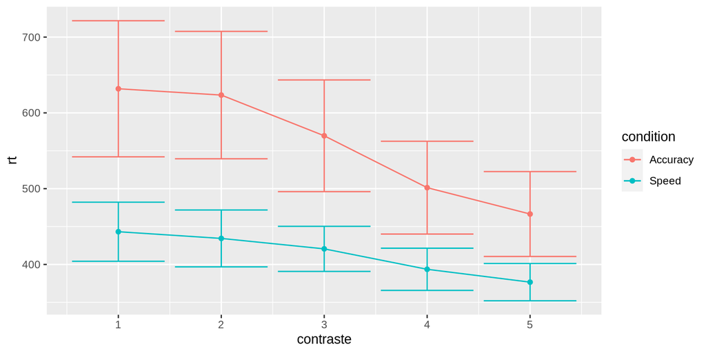

```r
library(ggplot2)
ind_means = aggregate(rt~participant*contraste*condition , data=prepocessed_df, mean)
means = aggregate(rt~contraste*condition , data=ind_means, mean)
means$std = aggregate(rt~contraste*condition , data=ind_means, sd)$rt

ggplot(data=means, aes(x=contraste, y=rt, group=condition)) +
  geom_line(aes(col=condition))+
  geom_point(aes(col=condition))+
  geom_errorbar( aes(x=contraste, ymin=rt-std, ymax=rt+std,col=condition))
```

# Last recommendations

- Use the documentation
- Learn how to duckduckgo (or google)

How do I group my participant ? | How do I subset my dataframe based on a column ?

- Always test your manipulations
- Use extension (e.g. dplyr, ggplot2,...) once you're familiar enough with base R

A sample of useful ressources :

- Danielle Navarro's amazing book : https://learningstatisticswithr.com/ (see also her github profile)
- R for data science : https://r4ds.had.co.nz/index.html
- (French) Initiation à la statistique avec R, Frédéric Bertrand et Myriam Maumy-Bertrand (2010!)